# Praktikum 1

# Library/Packages

```r
library("forecast")
```

```r
library("graphics")
library("TTR")
library("TSA")
```

# Impor Data

```r
library(readxl)
data1 <- read_excel("C:\\Users\\aisya\\Documents\\MATKUL\\Semester 5\\MPDW\\Data Suhu Maksimum Delhi (2).xlsx")

# menampilkan 5 data pertama
head(data1)
```

```
## # A tibble: 6 × 2
##   Tanggal             Suhu_Maks
##   <dttm>                  <dbl>
## 1 2024-08-07 00:00:00      30
## 2 2024-08-08 00:00:00      31.1
## 3 2024-08-09 00:00:00      31.1
## 4 2024-08-10 00:00:00      31.0
## 5 2024-08-11 00:00:00      31.0
## 6 2024-08-12 00:00:00      29.1
```

```r
data1$Tanggal <- as.Date(data1$Tanggal, format = "%d/%m/%Y")
```

# Eksplorasi Data

```r
View(data1)
str(data1)
```

```
## tibble [147 × 2] (S3: tbl_df/tbl/data.frame)
##  $ Tanggal  : Date[1:147], format: "2024-08-07" "2024-08-08" ...
##  $ Suhu_Maks: num [1:147] 30 31.1 31.1 31 31 ...
```

```r
dim(data1)
```

```
## [1] 147   2
```

Mengubah data agar terbaca sebagai data deret waktu dengan fungsi `ts()` .

```r
data1.ts <- ts(data1$Suhu_Maks)
```

Menampilkan ringkasan data

```r
summary(data1.ts)
```

```
##    Min. 1st Qu.  Median    Mean 3rd Qu.    Max.
##   16.00   25.09   31.00   28.64   32.07   35.02
```

Membuat plot data deret waktu

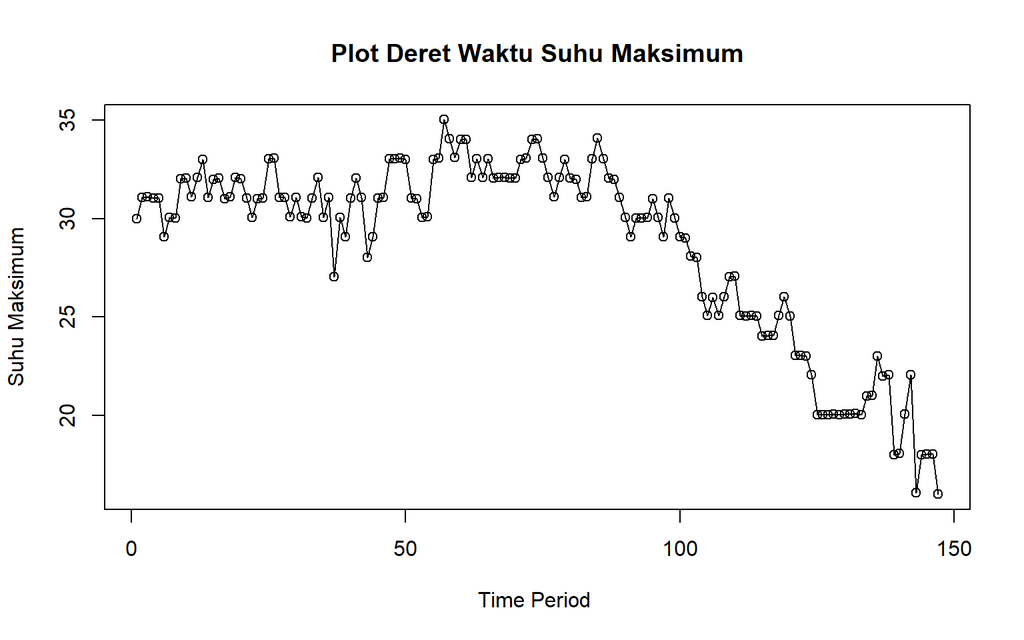

```r
ts.plot(data1.ts, xlab="Time Period ", ylab="Suhu Maksimum",
        main = "Plot Deret Waktu Suhu Maksimum")
points(data1.ts)
```

```r
#menyimpan plot
dev.copy(png, "plot_data1.png")
```

```r
dev.off()
```

# Pembagian Data

Pembagian data latih dan data uji dilakukan dengan perbandingan 80% data latih dan 20% data uji.

```r
# hitung jumlah data
n <- nrow(data1)

# tentukan batas 80%
n_train <- floor(0.8 * n)

# bagi data
training <- data1[1:n_train, ]
testing  <- data1[(n_train+1):n, ]

# ubah ke time series
train.ts <- ts(training$Suhu_Maks)
test.ts  <- ts(testing$Suhu_Maks)
```

Eksplorasi data dilakukan pada keseluruhan data, data latih serta data uji menggunakan plot data deret waktu.

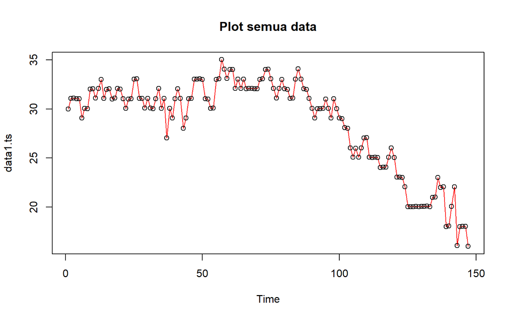

```r
#eksplorasi keseluruhan data
plot(data1.ts, col="red",main="Plot semua data")
points(data1.ts)
```

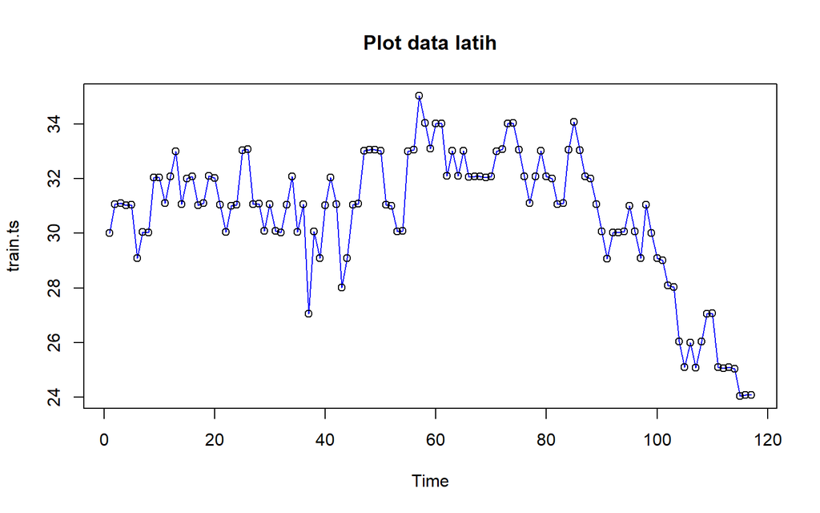

```r
#eksplorasi data latih
plot(train.ts, col="blue",main="Plot data latih")
points(train.ts)
```

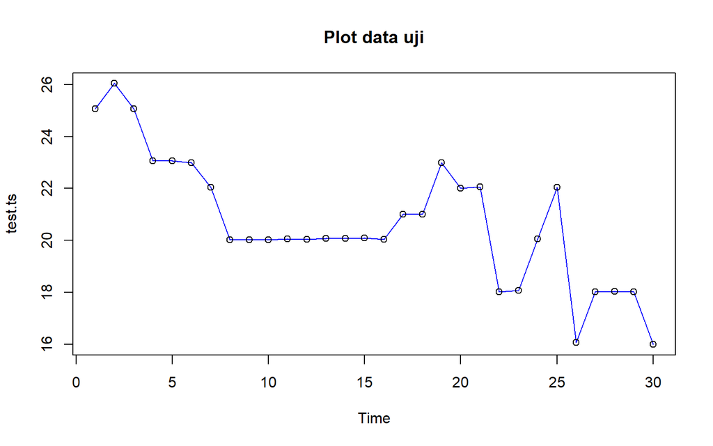

```r
#eksplorasi data uji
plot(test.ts, col="blue",main="Plot data uji")
points(test.ts)
```

Eksplorasi data dilakukan menggunakan package `ggplot2` dengan terlebih dahulu memanggil library *package* `ggplot2`.

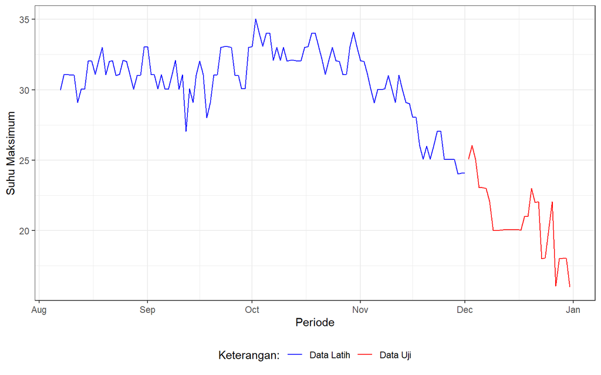

```r
library(ggplot2)
ggplot() +
  geom_line(data = training, aes(x = Tanggal, y = Suhu_Maks, col = "Data Latih")) +
  geom_line(data = testing, aes(x = Tanggal, y = Suhu_Maks, col = "Data Uji")) +
  labs(x = "Periode", y = "Suhu Maksimum", color = "Legend") +
   scale_colour_manual(name="Keterangan:", breaks = c("Data Latih", "Data Uji"),
                      values = c("blue", "red")) +
  theme_bw() + theme(legend.position = "bottom",
                     plot.caption = element_text(hjust=0.5, size=12))
```

# 🎯 Single Moving Average (SMA)

## Forecasting

Pemulusan menggunakan metode SMA dilakukan dengan parameter `m=4`.

```r
data.sma<-SMA(train.ts, n=4)
data.sma
```

```
## Time Series:
## Start = 1
## End = 117
## Frequency = 1
##   [1]      NA      NA      NA 30.7975 31.0575 30.5625 30.3025 30.0525 30.3000
##  [10] 31.0375 31.2975 31.8100 32.0525 31.8075 32.0350 32.0325 31.5375 31.5450
##  [19] 31.5675 31.5525 31.5575 31.2975 31.0275 30.7850 31.2850 32.0400 32.0525
##  [28] 32.0625 31.3225 30.8225 30.5775 30.3150 30.5550 30.8075 30.8000 31.0575
##  [37] 30.0600 29.5575 29.3175 29.3100 30.5575 30.8075 30.5375 30.0500 29.8000
##  [46] 29.8025 31.0550 32.0475 32.5525 33.0350 32.5400 32.0275 31.2775 30.5450
##  [55] 31.0350 31.5500 32.7900 33.7800 33.8025 34.0400 33.7900 33.3025 33.2850
##  [64] 32.8050 32.5550 32.5450 32.3100 32.3075 32.0625 32.0675 32.2975 32.5450
##  [73] 33.0375 33.5300 33.5450 33.2975 32.5675 32.0775 32.0650 32.0625 32.2900
##  [82] 32.0350 31.5550 31.8000 32.3200 32.8125 33.0575 32.7950 32.0425 31.3025
##  [91] 30.5500 30.0575 29.7950 29.7925 30.2775 30.2850 30.0525 30.3000 30.0525
## [100] 29.8100 29.7900 29.0475 28.5550 27.7925 26.8125 26.2925 25.5525 25.5500
## [109] 26.0400 26.3075 26.3100 26.0675 25.5775 25.0700 24.8075 24.5625 24.3100
```

Data pemulusan pada periode ke-t selanjutnya digunakan sebagai nilai peramalan pada periode ke t+1 sehingga hasil peramalan 1 periode kedepan adalah sebagai berikut.

```r
data.ramal<-c(NA,data.sma)
data.ramal #forecast 1 periode ke depan
```

```
##   [1]      NA      NA      NA      NA 30.7975 31.0575 30.5625 30.3025 30.0525
##  [10] 30.3000 31.0375 31.2975 31.8100 32.0525 31.8075 32.0350 32.0325 31.5375
##  [19] 31.5450 31.5675 31.5525 31.5575 31.2975 31.0275 30.7850 31.2850 32.0400
##  [28] 32.0525 32.0625 31.3225 30.8225 30.5775 30.3150 30.5550 30.8075 30.8000
##  [37] 31.0575 30.0600 29.5575 29.3175 29.3100 30.5575 30.8075 30.5375 30.0500
##  [46] 29.8000 29.8025 31.0550 32.0475 32.5525 33.0350 32.5400 32.0275 31.2775
##  [55] 30.5450 31.0350 31.5500 32.7900 33.7800 33.8025 34.0400 33.7900 33.3025
##  [64] 33.2850 32.8050 32.5550 32.5450 32.3100 32.3075 32.0625 32.0675 32.2975
##  [73] 32.5450 33.0375 33.5300 33.5450 33.2975 32.5675 32.0775 32.0650 32.0625
##  [82] 32.2900 32.0350 31.5550 31.8000 32.3200 32.8125 33.0575 32.7950 32.0425
##  [91] 31.3025 30.5500 30.0575 29.7950 29.7925 30.2775 30.2850 30.0525 30.3000
## [100] 30.0525 29.8100 29.7900 29.0475 28.5550 27.7925 26.8125 26.2925 25.5525
## [109] 25.5500 26.0400 26.3075 26.3100 26.0675 25.5775 25.0700 24.8075 24.5625
## [118] 24.3100
```

Selanjutnya dilakukan peramalan sebanyak 30 periode sesuai dengan jumlah data uji. Pada metode SMA, seluruh hasil peramalan untuk 30 periode ke depan akan memiliki nilai yang sama dengan hasil ramalan satu periode ke depan.

```r
data.gab<-cbind(
  aktual=c(data1.ts),
  pemulusan=c(data.sma,rep(NA,30)),
  ramalan=c(data.ramal,rep(data.ramal[length(data.ramal)],29)))

data.gab #forecast 30 periode ke depan
```

```
##        aktual pemulusan ramalan
##   [1,]  30.00        NA      NA
##   [2,]  31.07        NA      NA
##   [3,]  31.09        NA      NA
##   [4,]  31.03   30.7975      NA
##   [5,]  31.04   31.0575 30.7975
##   [6,]  29.09   30.5625 31.0575
##   [7,]  30.05   30.3025 30.5625
##   [8,]  30.03   30.0525 30.3025
##   [9,]  32.03   30.3000 30.0525
##  [10,]  32.04   31.0375 30.3000
##  [11,]  31.09   31.2975 31.0375
##  [12,]  32.08   31.8100 31.2975
##  [13,]  33.00   32.0525 31.8100
##  [14,]  31.06   31.8075 32.0525
```

[output cut: 133 more lines]

Adapun plot data deret waktu dari hasil peramalan yang dilakukan adalah sebagai berikut.

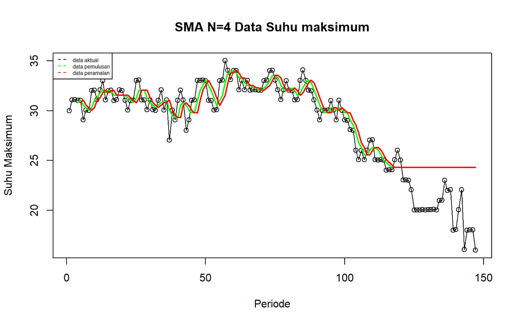

```r
ts.plot(data1.ts, xlab="Periode", ylab="Suhu Maksimum", main= "SMA N=4 Data Suhu maksimum")
points(data1.ts)
lines(data.gab[,2],col="green",lwd=2)
lines(data.gab[,3],col="red",lwd=2)
legend("topleft",c("data aktual","data pemulusan","data peramalan"), lty=8, col=c("black","green","red"), cex=0.5)
```

Selanjutnya perhitungan akurasi dilakukan dengan ukuran akurasi *Sum Squares Error* (SSE), *Mean Square Error* (MSE) dan *Mean Absolute Percentage Error* (MAPE). Perhitungan akurasi dilakukan baik pada data latih maupun pada data uji.

## Akurasi Data Latih

```r
#Menghitung nilai keakuratan data latih
error_train.sma = train.ts-data.ramal[1:length(train.ts)]

SSE_train.sma = sum(error_train.sma[5:length(train.ts)]^2)
MSE_train.sma = mean(error_train.sma[5:length(train.ts)]^2)
MAPE_train.sma = mean(abs((error_train.sma[5:length(train.ts)]/train.ts[5:length(train.ts)])*100))

akurasi_train.sma <- matrix(c(SSE_train.sma, MSE_train.sma, MAPE_train.sma))
row.names(akurasi_train.sma)<- c("SSE", "MSE", "MAPE")
colnames(akurasi_train.sma) <- c("Akurasi m = 4")
akurasi_train.sma
```

```
##      Akurasi m = 4
## SSE     205.267819
## MSE       1.816529
## MAPE      3.554069
```

Dalam hal ini nilai MAPE data latih pada metode pemulusan SMA sekitar 3,5%, nilai ini dapat dikategorikan sebagai nilai akurasi yang sangat baik. Selanjutnya dilakukan perhitungan nilai MAPE data uji pada metode pemulusan SMA.

## Akurasi Data Uji

```r
length(train.ts)
```

```
## [1] 117
```

```r
length(test.ts)
```

```
## [1] 30
```

```r
nrow(data.gab)
```

```
## [1] 147
```

```r
#Menghitung nilai keakuratan data uji
error_test.sma = test.ts-data.gab[118:147,3]

SSE_test.sma = sum(error_test.sma^2)
MSE_test.sma = mean(error_test.sma^2)
MAPE_test.sma = mean(abs((error_test.sma/test.ts*100)))

akurasi_test.sma <- matrix(c(SSE_test.sma, MSE_test.sma, MAPE_test.sma))
row.names(akurasi_test.sma)<- c("SSE", "MSE", "MAPE")
colnames(akurasi_test.sma) <- c("Akurasi m = 4")
akurasi_test.sma
```

```
##      Akurasi m = 4
## SSE      568.02010
## MSE       18.93400
## MAPE      19.89721
```

PPerhitungan akurasi menggunakan data uji menghasilkan nilai MAPE sebesar 19,8%. Berdasarkan kriteria MAPE, nilai tersebut berada pada rentang 10%–20%, sehingga metode peramalan dapat dikategorikan memiliki akurasi yang baik.

# 🎯 Double Moving Average (DMA)

## Forecasting

dilakukan peramalan untuk 30 periode kedepan menggunakan metode DMA

```r
dma <- SMA(data.sma, n = 4)
At <- 2*data.sma - dma
Bt <- 2/(4-1)*(data.sma - dma)
data.dma<- At+Bt
data.ramal2<- c(NA, data.dma)

t = 1:30
f = c()

for (i in t) {
  f[i] = At[length(At)] + Bt[length(Bt)]*(i)
}

data.gab2 <- cbind(aktual = c(data1.ts),
                   pemulusan1 = c(data.sma,rep(NA,30)),
                   pemulusan2 = c(dma, rep(NA,30)),
                   At = c(At, rep(NA,30)),
                   Bt = c(Bt,rep(NA,30)),
                   ramalan = c(data.ramal2, f[-1]))
data.gab2
```

```
##        aktual pemulusan1 pemulusan2       At           Bt  ramalan
##   [1,]  30.00         NA         NA       NA           NA       NA
##   [2,]  31.07         NA         NA       NA           NA       NA
##   [3,]  31.09         NA         NA       NA           NA       NA
##   [4,]  31.03    30.7975         NA       NA           NA       NA
##   [5,]  31.04    31.0575         NA       NA           NA       NA
##   [6,]  29.09    30.5625         NA       NA           NA       NA
##   [7,]  30.05    30.3025   30.68000 29.92500 -0.251666667       NA
##   [8,]  30.03    30.0525   30.49375 29.61125 -0.294166667 29.67333
##   [9,]  32.03    30.3000   30.30438 30.29563 -0.002916667 29.31708
##  [10,]  32.04    31.0375   30.42312 31.65188  0.409583333 30.29271
##  [11,]  31.09    31.2975   30.67188 31.92313  0.417083333 32.06146
##  [12,]  32.08    31.8100   31.11125 32.50875  0.465833333 32.34021
##  [13,]  33.00    32.0525   31.54937 32.55563  0.335416667 32.97458
##  [14,]  31.06    31.8075   31.74188 31.87313  0.043750000 32.89104
```

[output cut: 133 more lines]

Hasil pemulusan menggunakan metode DMA divisualisasikan sebagai berikut

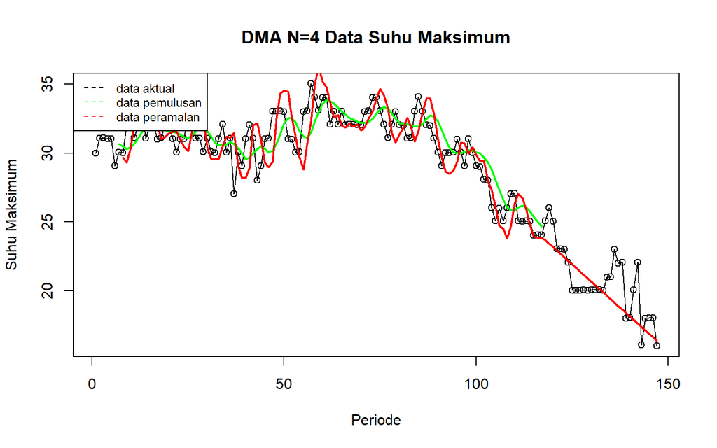

```r
ts.plot(data1.ts, xlab="Periode", ylab="Suhu Maksimum", main= "DMA N=4 Data Suhu Maksimum")
points(data1.ts)
lines(data.gab2[,3],col="green",lwd=2)
lines(data.gab2[,6],col="red",lwd=2)
legend("topleft",c("data aktual","data pemulusan","data peramalan"), lty=8, col=c("black","green","red"), cex=0.8)
```

Selanjutnya perhitungan akurasi dilakukan baik pada data latih maupun data uji. Perhitungan akurasi dilakukan dengan ukuran akurasi SSE, MSE dan MAPE.

## Akurasi Data Latih

```r
#Menghitung nilai keakuratan data latih
error_train.dma = train.ts-data.ramal2[1:length(train.ts)]

SSE_train.dma = sum(error_train.dma[8:length(train.ts)]^2)
MSE_train.dma = mean(error_train.dma[8:length(train.ts)]^2)
MAPE_train.dma = mean(abs((error_train.dma[8:length(train.ts)]/train.ts[8:length(train.ts)])*100))

akurasi_train.dma <- matrix(c(SSE_train.dma, MSE_train.dma, MAPE_train.dma))
row.names(akurasi_train.dma)<- c("SSE", "MSE", "MAPE")
colnames(akurasi_train.dma) <- c("Akurasi m = 4")
akurasi_train.dma
```

```
##      Akurasi m = 4
## SSE     285.293843
## MSE       2.593580
## MAPE      4.155457
```

Perhitungan akurasi pada data latih menggunakan nilai MAPE menghasilkan nilai MAPE yang kurang dari 10% sehingga dikategorikan sangat baik. Selanjutnya, perhitungan nilai akurasi dilakukan pada data uji.

## Akurasi Data Uji

```r
#Menghitung nilai keakuratan data uji
error_test.dma = test.ts-data.gab2[118:147,6]
SSE_test.dma = sum(error_test.dma^2)
MSE_test.dma = mean(error_test.dma^2)
MAPE_test.dma = mean(abs((error_test.dma/test.ts*100)))

akurasi_test.dma <- matrix(c(SSE_test.dma, MSE_test.dma, MAPE_test.dma))
row.names(akurasi_test.dma)<- c("SSE", "MSE", "MAPE")
colnames(akurasi_test.dma) <- c("Akurasi m = 4")
akurasi_test.dma
```

```
##      Akurasi m = 4
## SSE      94.197410
## MSE       3.139914
## MAPE      6.389434
```

Perhitungan akurasi menggunakan data uji menghasilkan nilai MAPE yang kurang dari 10% sehingga nilai akurasi ini dapat dikategorikan sebagai sangat baik.

Pada data latih, metode SMA lebih baik dibandingkan dengan metode DMA, sedangkan pada data uji, metode DMA lebih baik dibandingkan SMA.

# 🎯 Single Exponential Smoothing

## Forecasting dengan Fungsi ses

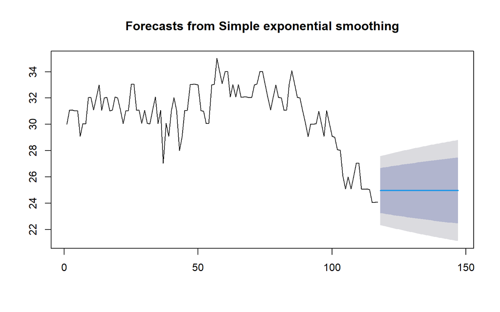

```r
#Cara 1 (fungsi ses)
ses.1 <- ses(train.ts, h = 30, alpha = 0.2)
plot(ses.1)
```

```r
ses.1
```

```
##     Point Forecast    Lo 80    Hi 80    Lo 95    Hi 95
## 118       24.96662 23.25581 26.67743 22.35016 27.58308
## 119       24.96662 23.22193 26.71131 22.29834 27.63490
## 120       24.96662 23.18869 26.74455 22.24751 27.68573
## 121       24.96662 23.15606 26.77717 22.19762 27.73562
## 122       24.96662 23.12402 26.80922 22.14860 27.78463
## 123       24.96662 23.09252 26.84072 22.10043 27.83281
## 124       24.96662 23.06154 26.87170 22.05305 27.88019
## 125       24.96662 23.03105 26.90218 22.00643 27.92681
## 126       24.96662 23.00104 26.93219 21.96053 27.97270
## 127       24.96662 22.97149 26.96175 21.91533 28.01791
## 128       24.96662 22.94236 26.99088 21.87078 28.06246
## 129       24.96662 22.91364 27.01959 21.82686 28.10637
## 130       24.96662 22.88533 27.04791 21.78356 28.14968
## 131       24.96662 22.85739 27.07585 21.74083 28.19241
```

[output cut: 16 more lines]

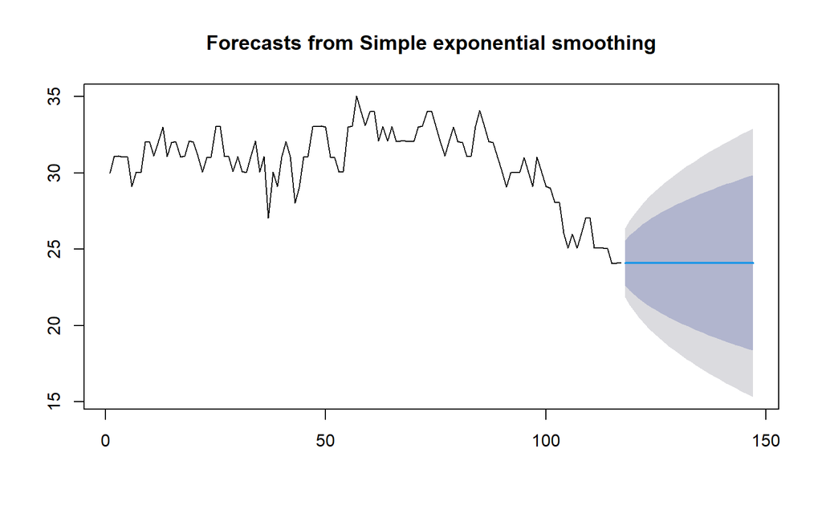

```r
ses.2<- ses(train.ts, h = 30, alpha = 0.7)
plot(ses.2)
```

```r
ses.2
```

```
##     Point Forecast    Lo 80    Hi 80    Lo 95    Hi 95
## 118       24.10416 22.63063 25.57769 21.85059 26.35773
## 119       24.10416 22.30549 25.90283 21.35333 26.85499
## 120       24.10416 22.03072 26.17760 20.93311 27.27521
## 121       24.10416 21.78833 26.41999 20.56240 27.64592
## 122       24.10416 21.56901 26.63932 20.22698 27.98135
## 123       24.10416 21.36720 26.84112 19.91834 28.28998
## 124       24.10416 21.17929 27.02903 19.63096 28.57737
## 125       24.10416 21.00274 27.20558 19.36095 28.84737
## 126       24.10416 20.83572 27.37261 19.10550 29.10282
## 127       24.10416 20.67682 27.53150 18.86250 29.34583
## 128       24.10416 20.52497 27.68335 18.63026 29.57806
## 129       24.10416 20.37931 27.82901 18.40749 29.80083
## 130       24.10416 20.23913 27.96919 18.19311 30.01522
## 131       24.10416 20.10386 28.10446 17.98623 30.22209
```

[output cut: 16 more lines]

Untuk mendapatkan gambar hasil pemulusan pada data latih dengan fungsi `ses()` , digunakan fungsi `autoplot()` dan `autolayer()` dari *library packages* `ggplot2` .

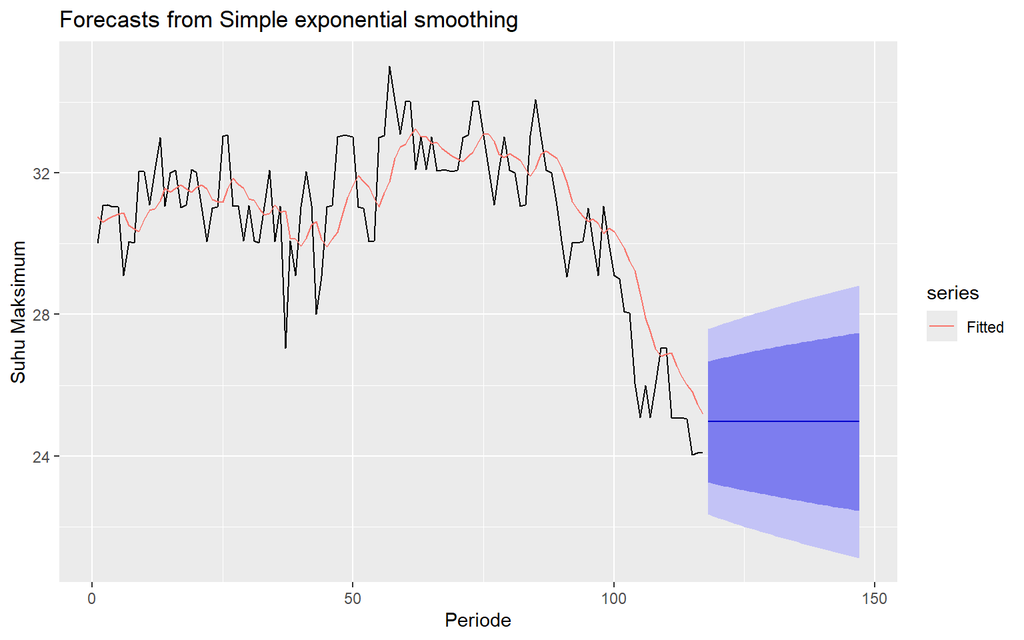

```r
autoplot(ses.1) +
  autolayer(fitted(ses.1), series="Fitted") +
  ylab("Suhu Maksimum") + xlab("Periode")
```

## Forecasting dengan Fungsi Holtwinters

Selanjutnya akan digunakan fungsi `HoltWinters()` dengan nilai inisialisasi parameter dan panjang periode peramalan yang sama dengan fungsi `ses()` .

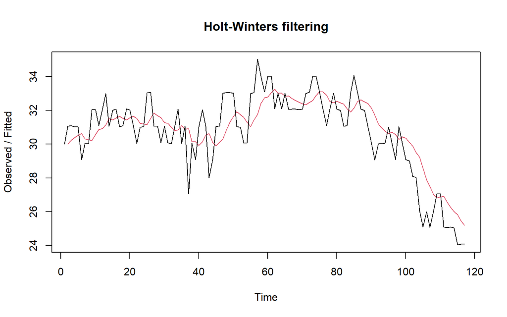

```r
#Cara 2 (fungsi Holtwinter)
ses1<- HoltWinters(train.ts, gamma = FALSE, beta = FALSE, alpha = 0.2)
plot(ses1)
```

```r
#ramalan
ramalan1<- forecast(ses1, h=30)
ramalan1
```

```
##     Point Forecast    Lo 80    Hi 80    Lo 95    Hi 95
## 118       24.96662 23.27217 26.66107 22.37518 27.55806
## 119       24.96662 23.23861 26.69463 22.32386 27.60938
## 120       24.96662 23.20569 26.72754 22.27352 27.65972
## 121       24.96662 23.17338 26.75986 22.22410 27.70914
## 122       24.96662 23.14164 26.79160 22.17555 27.75768
## 123       24.96662 23.11044 26.82280 22.12784 27.80540
## 124       24.96662 23.07976 26.85348 22.08092 27.85232
## 125       24.96662 23.04957 26.88367 22.03474 27.89850
## 126       24.96662 23.01984 26.91339 21.98928 27.94395
## 127       24.96662 22.99057 26.94267 21.94451 27.98873
## 128       24.96662 22.96172 26.97152 21.90039 28.03285
## 129       24.96662 22.93328 26.99996 21.85689 28.07634
## 130       24.96662 22.90523 27.02801 21.81400 28.11924
## 131       24.96662 22.87756 27.05568 21.77168 28.16156
```

[output cut: 16 more lines]

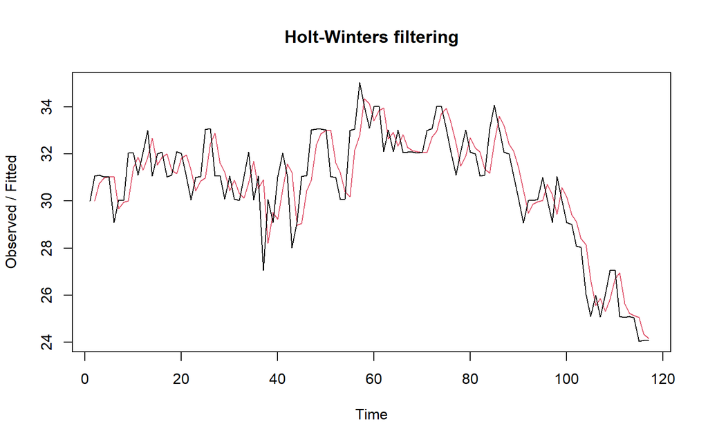

```r
ses2<- HoltWinters(train.ts, gamma = FALSE, beta = FALSE, alpha = 0.7)
plot(ses2)
```

```r
#ramalan
ramalan2<- forecast(ses2, h=30)
ramalan2
```

```
##     Point Forecast    Lo 80    Hi 80    Lo 95    Hi 95
## 118       24.10416 22.63306 25.57526 21.85431 26.35401
## 119       24.10416 22.30846 25.89987 21.35787 26.85046
## 120       24.10416 22.03414 26.17418 20.93834 27.26999
## 121       24.10416 21.79215 26.41618 20.56824 27.64008
## 122       24.10416 21.57319 26.63514 20.23337 27.97495
## 123       24.10416 21.37171 26.83661 19.92524 28.28308
## 124       24.10416 21.18411 27.02421 19.63833 28.56999
## 125       24.10416 21.00785 27.20047 19.36877 28.83955
## 126       24.10416 20.84110 27.36722 19.11375 29.09458
## 127       24.10416 20.68247 27.52585 18.87114 29.33719
## 128       24.10416 20.53087 27.67745 18.63929 29.56904
## 129       24.10416 20.38545 27.82287 18.41688 29.79144
## 130       24.10416 20.24550 27.96282 18.20285 30.00547
## 131       24.10416 20.11046 28.09787 17.99632 30.21200
```

[output cut: 16 more lines]

Nilai parameter $\alpha$ dari kedua fungsi dapat dioptimalkan menyesuaikan dari *error*-nya paling minimumnya. Caranya adalah dengan membuat parameter $\alpha =$ `NULL` .

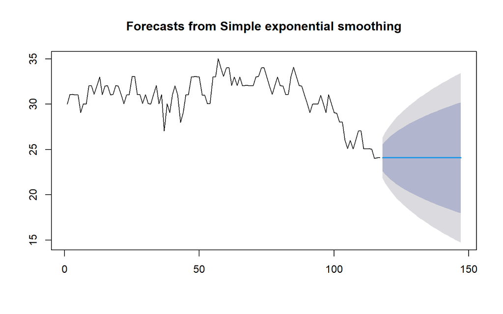

```r
#SES
ses.opt <- ses(train.ts, h = 30, alpha = NULL)
plot(ses.opt)
```

```r
ses.opt
```

```
##     Point Forecast    Lo 80    Hi 80    Lo 95    Hi 95
## 118       24.09361 22.62133 25.56588 21.84195 26.34526
## 119       24.09361 22.25423 25.93298 21.28052 26.90669
## 120       24.09361 21.94907 26.23814 20.81383 27.37339
## 121       24.09361 21.68223 26.50498 20.40573 27.78149
## 122       24.09361 21.44211 26.74510 20.03849 28.14872
## 123       24.09361 21.22199 26.96522 19.70186 28.48536
## 124       24.09361 21.01759 27.16962 19.38925 28.79796
## 125       24.09361 20.82595 27.36126 19.09616 29.09105
## 126       24.09361 20.64494 27.54227 18.81933 29.36788
## 127       24.09361 20.47297 27.71424 18.55632 29.63089
## 128       24.09361 20.30881 27.87840 18.30526 29.88196
## 129       24.09361 20.15147 28.03574 18.06463 30.12258
## 130       24.09361 20.00018 28.18703 17.83325 30.35396
## 131       24.09361 19.85429 28.33292 17.61013 30.57708
```

[output cut: 16 more lines]

```r
#Lamda Optimum Holt Winter
HWopt<- HoltWinters(train.ts, gamma = FALSE, beta = FALSE,alpha = NULL)
HWopt
```

```
## Holt-Winters exponential smoothing without trend and without seasonal component.
##
## Call:
## HoltWinters(x = train.ts, alpha = NULL, beta = FALSE, gamma = FALSE)
##
## Smoothing parameters:
##  alpha: 0.7518291
##  beta : FALSE
##  gamma: FALSE
##
## Coefficients:
##      [,1]
## a 24.0931
```

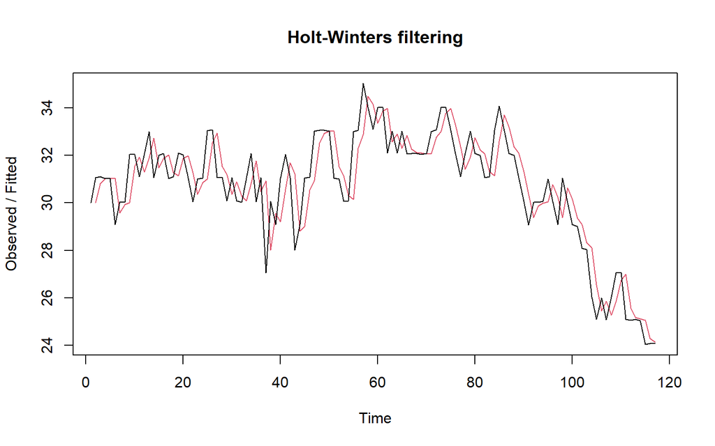

```r
plot(HWopt)
```

```r
#ramalan
ramalanopt<- forecast(HWopt, h=30)
ramalanopt
```

```
##     Point Forecast    Lo 80    Hi 80    Lo 95    Hi 95
## 118        24.0931 22.62304 25.56316 21.84484 26.34136
## 119        24.0931 22.25391 25.93229 21.28030 26.90590
## 120        24.0931 21.94737 26.23883 20.81149 27.37471
## 121        24.0931 21.67945 26.50675 20.40174 27.78446
## 122        24.0931 21.43843 26.74777 20.03314 28.15306
## 123        24.0931 21.21755 26.96865 19.69532 28.49088
## 124        24.0931 21.01246 27.17374 19.38167 28.80453
## 125        24.0931 20.82020 27.36600 19.08763 29.09857
## 126        24.0931 20.63862 27.54758 18.80993 29.37627
## 127        24.0931 20.46612 27.72008 18.54612 29.64008
## 128        24.0931 20.30146 27.88474 18.29429 29.89191
## 129        24.0931 20.14366 28.04254 18.05296 30.13324
## 130        24.0931 19.99193 28.19427 17.82090 30.36530
## 131        24.0931 19.84561 28.34059 17.59713 30.58907
```

[output cut: 16 more lines]

Setelah dilakukan peramalan, akan dilakukan perhitungan keakuratan hasil peramalan. Perhitungan akurasi ini dilakukan baik pada data latih dan data uji.

## Akurasi Data Latih

Perhitungan akurasi data dapat dilakukan dengan cara langsung maupun manual. Secara langsung, nilai akurasi dapat diambil dari objek yang tersimpan pada hasil SES, yaitu *sum of squared errors* (SSE). Nilai akurasi lain dapat dihitung pula dari nilai SSE tersebut.

```r
#Keakuratan Metode
#Pada data training

# SES dengan alpha = 0.2
SSE1<-ses1$SSE
MSE1<-ses1$SSE/length(train.ts)
RMSE1<-sqrt(MSE1)

akurasi1 <- matrix(c(SSE1,MSE1,RMSE1))
row.names(akurasi1)<- c("SSE", "MSE", "RMSE")
colnames(akurasi1) <- c("Akurasi lamda=0.2")
akurasi1
```

```
##      Akurasi lamda=0.2
## SSE         206.500456
## MSE           1.764961
## RMSE          1.328518
```

```r
# SES dengan alpha = 0.7
SSE2<-ses2$SSE
MSE2<-ses2$SSE/length(train.ts)
RMSE2<-sqrt(MSE2)

akurasi2 <- matrix(c(SSE2,MSE2,RMSE2))
row.names(akurasi2)<- c("SSE", "MSE", "RMSE")
colnames(akurasi2) <- c("Akurasi lamda=0.7")
akurasi2
```

```
##      Akurasi lamda=0.7
## SSE         152.145511
## MSE           1.300389
## RMSE          1.140346
```

```r
#Cara Manual
# Alpha = 0.2
sisaan1<-ramalan1$residuals
head(sisaan1)
```

```
## Time Series:
## Start = 1
## End = 6
## Frequency = 1
## [1]        NA  1.070000  0.876000  0.640800  0.522640 -1.531888
```

```r
SSE.1=sum(sisaan1[2:length(train.ts)]^2)
SSE.1
```

```
## [1] 206.5005
```

```r
MSE.1 = SSE.1/length(train.ts)
MSE.1
```

```
## [1] 1.764961
```

```r
MAPE.1 = sum(abs(sisaan1[2:length(train.ts)]/train.ts[2:length(train.ts)])*
               100)/length(train.ts)
MAPE.1
```

```
## [1] 3.645695
```

```r
akurasi.1 <- matrix(c(SSE.1,MSE.1,MAPE.1))
row.names(akurasi.1)<- c("SSE", "MSE", "MAPE")
colnames(akurasi.1) <- c("Akurasi lamda=0.2")
akurasi.1
```

```
##      Akurasi lamda=0.2
## SSE         206.500456
## MSE           1.764961
## MAPE          3.645695
```

```r
# Alpha = 0.7
sisaan2<-ramalan2$residuals
head(sisaan2)
```

```
## Time Series:
## Start = 1
## End = 6
## Frequency = 1
## [1]        NA  1.070000  0.341000  0.042300  0.022690 -1.943193
```

```r
SSE.2=sum(sisaan2[2:length(train.ts)]^2)
SSE.2
```

```
## [1] 152.1455
```

```r
MSE.2 = SSE.2/length(train.ts)
MSE.2
```

```
## [1] 1.300389
```

```r
MAPE.2 = sum(abs(sisaan2[2:length(train.ts)]/train.ts[2:length(train.ts)])*
               100)/length(train.ts)
MAPE.2
```

```
## [1] 2.933232
```

```r
akurasi.2 <- matrix(c(SSE.2,MSE.2,MAPE.2))
row.names(akurasi.2)<- c("SSE", "MSE", "MAPE")
colnames(akurasi.2) <- c("Akurasi lamda=0.7")
akurasi.2
```

```
##      Akurasi lamda=0.7
## SSE         152.145511
## MSE           1.300389
## MAPE          2.933232
```

Berdasarkan nilai SSE, MSE, RMSE, dan MAPE di antara kedua parameter, nilai parameter $\lambda=0,7$ menghasilkan akurasi yang lebih baik dibanding $\lambda=0,2$ . Hal ini dilihat dari nilai masing-masing ukuran akurasi yang lebih kecil. Berdasarkan nilai MAPE-nya, hasil ini dapat dikategorikan sebagai peramalan sangat baik.

## Akurasi Data Uji

Akurasi data uji dapat dihitung dengan cara yang hampir sama dengan perhitungan akurasi data latih.

```r
# jumlah observasi uji
n_test <- nrow(testing)

# error (ramalan - aktual), samakan panjang dan tipe numeric
e1   <- as.numeric(ramalan1$mean)[1:n_test] - as.numeric(testing$Suhu_Maks)
e2   <- as.numeric(ramalan2$mean)[1:n_test] - as.numeric(testing$Suhu_Maks)
eopt <- as.numeric(ramalanopt$mean)[1:n_test] - as.numeric(testing$Suhu_Maks)

# SSE / MSE / RMSE untuk masing-masing model (abaikan NA)
SSEtesting1  <- sum(e1^2,  na.rm = TRUE)
MSEtesting1  <- mean(e1^2, na.rm = TRUE)
RMSEtesting1 <- sqrt(MSEtesting1)

SSEtesting2  <- sum(e2^2,  na.rm = TRUE)
MSEtesting2  <- mean(e2^2, na.rm = TRUE)
RMSEtesting2 <- sqrt(MSEtesting2)

SSEtestingopt  <- sum(eopt^2,  na.rm = TRUE)
MSEtestingopt  <- mean(eopt^2, na.rm = TRUE)
RMSEtestingopt <- sqrt(MSEtestingopt)

# Tabel ringkas
akurasitesting_SSE <- matrix(c(SSEtesting1, SSEtesting2, SSEtestingopt),
                             nrow = 3,
                             dimnames = list(c("SSE1","SSE2","SSEopt"), "Nilai"))
akurasitesting_MSE <- matrix(c(MSEtesting1, MSEtesting2, MSEtestingopt),
                             nrow = 3,
                             dimnames = list(c("MSE1","MSE2","MSEopt"), "Nilai"))
akurasitesting_RMSE <- matrix(c(RMSEtesting1, RMSEtesting2, RMSEtestingopt),
                              nrow = 3,
                              dimnames = list(c("RMSE1","RMSE2","RMSEopt"), "Nilai"))

akurasitesting_SSE
```

```
##           Nilai
## SSE1   722.8497
## SSE2   524.8095
## SSEopt 522.5593
```

```r
akurasitesting_MSE
```

```
##           Nilai
## MSE1   24.09499
## MSE2   17.49365
## MSEopt 17.41864
```

```r
akurasitesting_RMSE
```

```
##            Nilai
## RMSE1   4.908665
## RMSE2   4.182541
## RMSEopt 4.173565
```

Selain dengan cara di atas, perhitungan nilai akurasi dapat menggunakan fungsi `accuracy()` dari *package* `forecast`.

```r
accuracy(ramalan1, testing$Suhu_Maks)
```

```
##                      ME     RMSE      MAE         MPE      MAPE     MASE
## Training set -0.2169561 1.334232 1.101633  -0.9723126  3.677123 1.259505
## Test set     -4.2582849 4.908665 4.342961 -22.2683179 22.595455 4.965341
##                   ACF1
## Training set 0.5274826
## Test set            NA
```

```r
accuracy(ramalan2, testing$Suhu_Maks)
```

```
##                       ME     RMSE       MAE         MPE      MAPE     MASE
## Training set -0.07260885 1.145251 0.8999991  -0.3624356  2.958518 1.028976
## Test set     -3.39582806 4.182541 3.6529958 -18.0446322 19.051356 4.176498
##                    ACF1
## Training set 0.06622079
## Test set             NA
```

```r
accuracy(ramalanopt, testing$Suhu_Maks)
```

```
##                       ME     RMSE       MAE         MPE      MAPE     MASE
## Training set -0.06773022 1.144146 0.8953944  -0.3405485  2.942493 1.023711
## Test set     -3.38476628 4.173565 3.6441464 -17.9904596 19.005900 4.166381
##                    ACF1
## Training set 0.01996787
## Test set             NA
```

Hasil menunjukkan bahwa metode SES dengan parameter optimal merupakan metode terbaik karena menghasilkan nilai error atau ukuran akurasi yang paling kecil dibandingkan metode lainnya.

# 🎯 *Double Exponential Smoothing* (DES)

## Forecasting dengan Fungsi Holtwinters

Pemulusan dengan metode DES kali ini akan menggunakan fungsi `HoltWinters()` . Jika sebelumnya nilai argumen `beta` dibuat `FALSE` , kali ini argumen tersebut akan diinisialisasi bersamaan dengan nilai `alpha` .

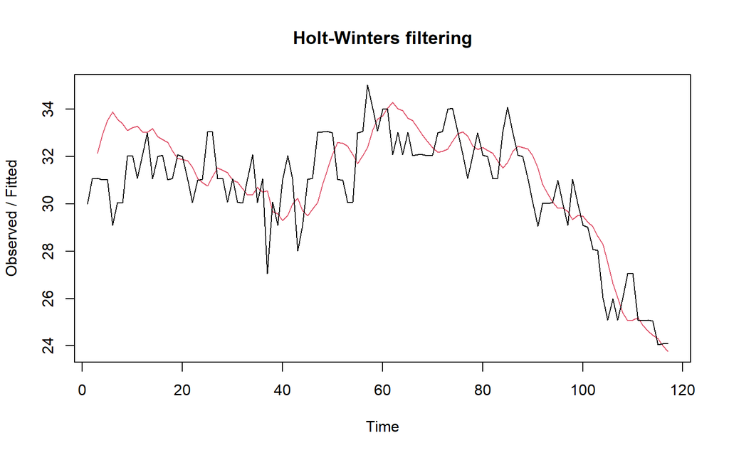

```r
#Lamda=0.2 dan gamma=0.2
des.1<- HoltWinters(train.ts, gamma = FALSE, beta = 0.2, alpha = 0.2)
plot(des.1)
```

```r
#ramalan
ramalandes1<- forecast(des.1, h=30)
ramalandes1
```

```
##     Point Forecast     Lo 80    Hi 80     Lo 95    Hi 95
## 118       23.58328 21.738248 25.42832 20.761545 26.40502
## 119       23.34081 21.443378 25.23823 20.438939 26.24267
## 120       23.09833 21.131830 25.06483 20.090827 26.10583
## 121       22.85585 20.802634 24.90907 19.715725 25.99598
## 122       22.61338 20.455394 24.77136 19.313027 25.91372
## 123       22.37090 20.090208 24.65159 18.882883 25.85891
## 124       22.12842 19.707555 24.54929 18.426026 25.83082
## 125       21.88594 19.308172 24.46372 17.943581 25.82831
## 126       21.64347 18.892941 24.39399 17.436900 25.85004
## 127       21.40099 18.462804 24.33918 16.907423 25.89456
## 128       21.15851 18.018699 24.29833 16.356582 25.96045
## 129       20.91604 17.561521 24.27055 15.785748 26.04633
## 130       20.67356 17.092100 24.25502 15.196189 26.15093
## 131       20.43108 16.611191 24.25098 14.589063 26.27310
```

[output cut: 16 more lines]

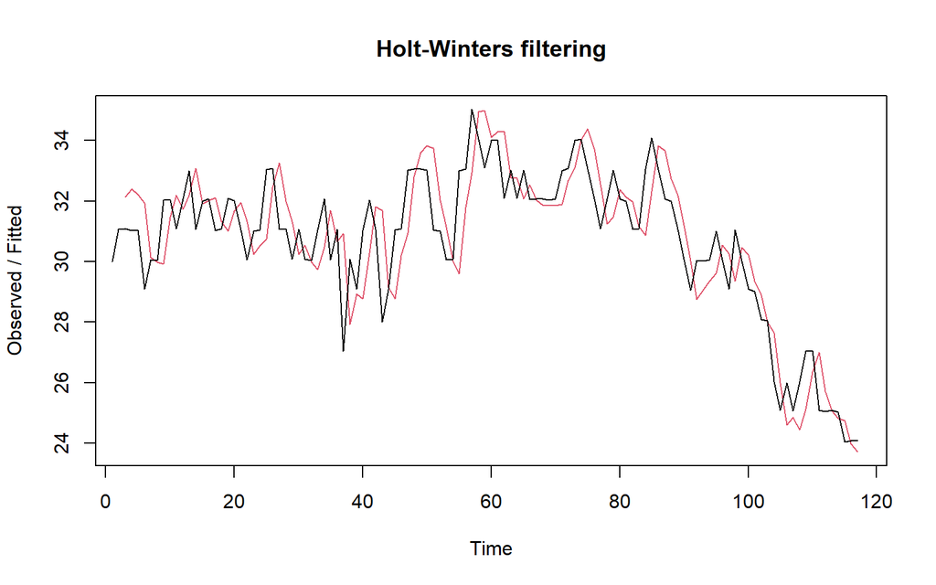

```r
#Lamda=0.6 dan gamma=0.3
des.2<- HoltWinters(train.ts, gamma = FALSE, beta = 0.3, alpha = 0.6)
plot(des.2)
```

```r
#ramalan
ramalandes2<- forecast(des.2, h=30)
ramalandes2
```

```
##     Point Forecast       Lo 80    Hi 80       Lo 95    Hi 95
## 118       23.67925  21.9931968 25.36531  21.1006515 26.25786
## 119       23.42261  21.2843050 25.56091  20.1523549 26.69286
## 120       23.16596  20.4841248 25.84780  19.0644447 27.26748
## 121       22.90932  19.6098107 26.20883  17.8631564 27.95548
## 122       22.65267  18.6727195 26.63263  16.5658590 28.73949
## 123       22.39603  17.6804885 27.11157  15.1842324 29.60782
## 124       22.13938  16.6384912 27.64028  13.7264948 30.55227
## 125       21.88274  15.5506976 28.21478  12.1987178 31.56676
## 126       21.62609  14.4201717 28.83201  10.6055875 32.64660
## 127       21.36945  13.2493666 29.48953   8.9508554 33.78804
## 128       21.11280  12.0403056 30.18530   7.2376160 34.98799
## 129       20.85616  10.7946981 30.91762   5.4684835 36.24383
## 130       20.59951   9.5140164 31.68501   3.6457097 37.55331
## 131       20.34287   8.1995489 32.48618   1.7712649 38.91447
```

[output cut: 16 more lines]

#### Perbandingan plot data latih dan data uji

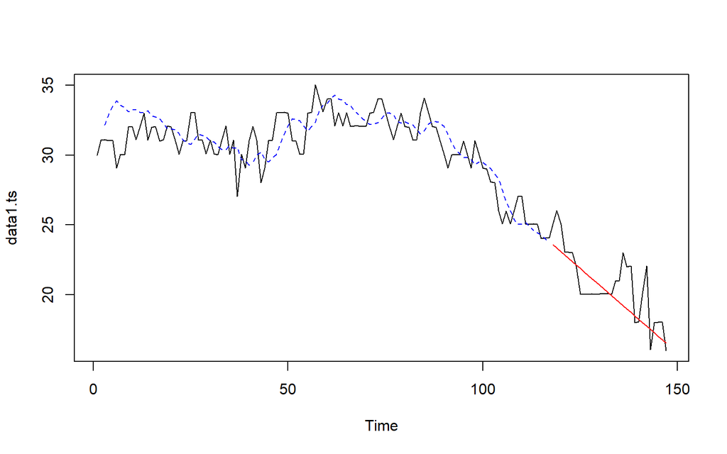

```r
plot(data1.ts)
lines(des.1$fitted[,1], lty=2, col="blue")
lines(ramalandes1$mean, col="red")
```

Untuk mendapatkan nilai parameter optimum dari DES, argumen `alpha` dan `beta` dapat dibuat `NULL` seperti berikut.

```r
#Lamda dan gamma optimum
des.opt<- HoltWinters(train.ts, gamma = FALSE)
des.opt
```

```
## Holt-Winters exponential smoothing with trend and without seasonal component.
##
## Call:
## HoltWinters(x = train.ts, gamma = FALSE)
##
## Smoothing parameters:
##  alpha: 0.8263698
##  beta : 0.07942237
##  gamma: FALSE
##
## Coefficients:
##         [,1]
## a 24.0302579
## b -0.2366969
```

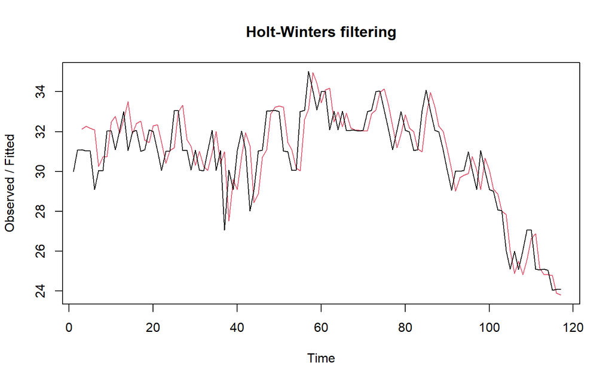

```r
plot(des.opt)
```

```r
#ramalan
ramalandesopt<- forecast(des.opt, h=30)
ramalandesopt
```

```
##     Point Forecast     Lo 80    Hi 80      Lo 95    Hi 95
## 118       23.79356 22.241391 25.34573 21.4197219 26.16740
## 119       23.55686 21.476917 25.63681 20.3758599 26.73787
## 120       23.32017 20.763686 25.87665 19.4103663 27.22997
## 121       23.08347 20.073779 26.09316 18.4805447 27.68640
## 122       22.84677 19.394981 26.29857 17.5677130 28.12583
## 123       22.61008 18.720831 26.49932 16.6619881 28.55816
## 124       22.37338 18.047516 26.69924 15.7575425 28.98922
## 125       22.13668 17.372629 26.90074 14.8506919 29.42267
## 126       21.89999 16.694573 27.10540 13.9389941 29.86098
## 127       21.66329 16.012254 27.31432 13.0207762 30.30580
## 128       21.42659 15.324904 27.52828 12.0948654 30.75832
## 129       21.18990 14.631979 27.74781 11.1604273 31.21936
## 130       20.95320 13.933086 27.97331 10.2168636 31.68953
## 131       20.71650 13.227946 28.20506  9.2637444 32.16926
```

[output cut: 16 more lines]

Selanjutnya akan dilakukan perhitungan akurasi pada data latih maupun data uji dengan ukuran akurasi SSE, MSE dan MAPE.

## Akurasi Data Latih

```r
#Akurasi Data Training
ssedes.train1<-des.1$SSE
msedes.train1<-ssedes.train1/length(train.ts)
sisaandes1<-ramalandes1$residuals
head(sisaandes1)
```

```
## Time Series:
## Start = 1
## End = 6
## Frequency = 1
## [1]        NA        NA -1.050000 -1.928000 -2.483280 -4.788173
```

```r
mapedes.train1 <- sum(abs(sisaandes1[3:length(train.ts)]/train.ts[3:length(train.ts)])
                      *100)/length(train.ts)

akurasides.1 <- matrix(c(ssedes.train1,msedes.train1,mapedes.train1))
row.names(akurasides.1)<- c("SSE", "MSE", "MAPE")
colnames(akurasides.1) <- c("Akurasi lamda=0.2 dan gamma=0.2")
akurasides.1
```

```
##      Akurasi lamda=0.2 dan gamma=0.2
## SSE                       245.650186
## MSE                         2.099574
## MAPE                        3.720026
```

```r
ssedes.train2<-des.2$SSE
msedes.train2<-ssedes.train2/length(train.ts)
sisaandes2<-ramalandes2$residuals
head(sisaandes2)
```

```
## Time Series:
## Start = 1
## End = 6
## Frequency = 1
## [1]        NA        NA -1.050000 -1.361000 -1.170420 -2.843512
```

```r
mapedes.train2 <- sum(abs(sisaandes2[3:length(train.ts)]/train.ts[3:length(train.ts)])
                      *100)/length(train.ts)

akurasides.2 <- matrix(c(ssedes.train2,msedes.train2,mapedes.train2))
row.names(akurasides.2)<- c("SSE", "MSE", "MAPE")
colnames(akurasides.2) <- c("Akurasi lamda=0.6 dan gamma=0.3")
akurasides.2
```

```
##      Akurasi lamda=0.6 dan gamma=0.3
## SSE                       197.795367
## MSE                         1.690559
## MAPE                        3.321433
```

Hasil akurasi dari data latih didapatkan skenario 2 dengan lamda=0.6 dan gamma=0.3 memiliki hasil yang lebih baik. Namun untuk kedua skenario dapat dikategorikan peramalan sangat baik berdasarkan nilai MAPE-nya.

## Akurasi Data Uji

```r
#Akurasi Data Testing
selisihdes1<-ramalandes1$mean-testing$Suhu_Maks
selisihdes1
```

```
## Time Series:
## Start = 118
## End = 147
## Frequency = 1
##  [1] -1.48671694 -2.69919385 -1.96167075 -0.20414765 -0.44662455 -0.62910146
##  [7]  0.07842164  1.85594474  1.62346783  1.37099093  1.09851403  0.86603713
## [13]  0.60356022  0.36108332  0.09860642 -0.09387048 -1.29634739 -1.54882429
## [19] -3.78130119 -3.03377810 -3.32625500  0.47126810  0.17879120 -2.05368571
## [25] -4.28616261  1.44136049 -0.74111641 -1.00359332 -1.23607022  0.55145288
```

```r
SSEtestingdes1<-sum(selisihdes1^2)
MSEtestingdes1<-SSEtestingdes1/length(testing$Suhu_Maks)
MAPEtestingdes1<-sum(abs(selisihdes1/testing$Suhu_Maks)*100)/length(testing$Suhu_Maks)

selisihdes2<-ramalandes2$mean-testing$Suhu_Maks
selisihdes2
```

```
## Time Series:
## Start = 118
## End = 147
## Frequency = 1
##  [1] -1.390745169 -2.617390429 -1.894035689 -0.150680949 -0.407326209
##  [6] -0.603971469  0.089383271  1.852738011  1.606092751  1.339447491
## [11]  1.052802231  0.806156971  0.529511711  0.272866451 -0.003778809
## [16] -0.210424069 -1.427069329 -1.693714589 -3.940359849 -3.207005108
## [21] -3.513650368  0.269704372 -0.036940888 -2.283586148 -4.530231408
## [26]  1.183123332 -1.013521928 -1.290167188 -1.536812448  0.236542292
```

```r
SSEtestingdes2<-sum(selisihdes2^2)
MSEtestingdes2<-SSEtestingdes2/length(testing$Suhu_Maks)
MAPEtestingdes2<-sum(abs(selisihdes2/testing$Suhu_Maks)*100)/length(testing$Suhu_Maks)

selisihdesopt<-ramalandesopt$mean-testing$Suhu_Maks
selisihdesopt
```

```
## Time Series:
## Start = 118
## End = 147
## Frequency = 1
##  [1] -1.27643904 -2.48313594 -1.73983284  0.02347026 -0.21322664 -0.38992353
##  [7]  0.32337957  2.10668267  1.87998577  1.63328887  1.36659197  1.13989508
## [13]  0.88319818  0.64650128  0.38980438  0.20310748 -0.99358942 -1.24028632
## [19] -3.46698321 -2.71368011 -3.00037701  0.80292609  0.51622919 -1.71046771
## [25] -3.93716460  1.79613850 -0.38055840 -0.63725530 -0.86395220  0.92935090
```

```r
SSEtestingdesopt<-sum(selisihdesopt^2)
MSEtestingdesopt<-SSEtestingdesopt/length(testing$Suhu_Maks)
MAPEtestingdesopt<-sum(abs(selisihdesopt/testing$Suhu_Maks)*100)/length(testing$Suhu_Maks)

akurasitestingdes <-
  matrix(c(SSEtestingdes1,MSEtestingdes1,MAPEtestingdes1,SSEtestingdes2,MSEtestingdes2,
           MAPEtestingdes2,SSEtestingdesopt,MSEtestingdesopt,MAPEtestingdesopt),
         nrow=3,ncol=3)
row.names(akurasitestingdes)<- c("SSE", "MSE", "MAPE")
colnames(akurasitestingdes) <- c("des ske1","des ske2","des opt")
akurasitestingdes
```

```
##       des ske1  des ske2   des opt
## SSE  91.371156 98.280774 81.960250
## MSE   3.045705  3.276026  2.732008
## MAPE  6.362913  6.438556  6.321415
```

Hasil menunjukkan bahwa metode DES dengan parameter optimal merupakan metode terbaik karena menghasilkan nilai error atau ukuran akurasi yang paling kecil dibandingkan metode lainnya.

## Perbandingan SES dan DES

```r
MSEfull <-
  matrix(c(MSEtesting1,MSEtesting2,MSEtestingopt,MSEtestingdes1,MSEtestingdes2,
           MSEtestingdesopt),nrow=3,ncol=2)
row.names(MSEfull)<- c("ske 1", "ske 2", "ske opt")
colnames(MSEfull) <- c("ses","des")
MSEfull
```

```
##              ses      des
## ske 1   24.09499 3.045705
## ske 2   17.49365 3.276026
## ske opt 17.41864 2.732008
```

Kedua metode dibandingkan dengan menggunakan ukuran akurasi yang sama, yaitu akurasi MSE. Hasilnya didapatkan metode DES lebih baik dibandingkan metode SES dilihat dari MSE yang lebih kecil nilainya.

# 📋 Kesimpulan Metode Terbaik

Berdasarkan hasil evaluasi metrik, DES dengan parameter optimal adalah metode peramalan terbaik untuk data suhu maksimum ini, dengan MSE data uji paling rendah (2,73) dibanding DMA (3,14) dan jauh lebih baik dibanding SES yang MSE-nya berkisar 17,42 sampai 24,10 tergantung parameter alpha yang dipakai. Hal ini karena DES mampu menangkap pola tren pada data, sedangkan SES hanya menangkap komponen level sehingga errornya jauh lebih besar.